# Разведочный анализ данных об убийства в США 1980-1984 года

Variant == “2”

###1) Аннотация Данная работа включает себя анализ данных и их интерпретацию,выведенние заключения насчет тенденций убийств в США. Это позволяет детально разобраться в данной сфере, что полезно как для протсых жителей, так и для стражей порядка, позволит объяснить, что конкретно нуждается в улучшении или контроле.

###2) Введение Набор данных содержит более 100000 случаев убийств на территории США в 1980-1984 годах. Присутсвует информация о: возрастах убийцы и жертвы, их национальности, их взаимоотношениях, месте преступления (город, штат), дате убийства (месяц и год), орудии убийства и организации, расследующей преступление. В основном это категоральные переменные. Задача: Данное исследование признано выявить тренды и взаимосвязи в уголовных делах (убийствах), произошедших на территории США в период с 1980-1984 года. Анализ данных даст понимание о фактах, связанных непосредственно с убийствами, что будет являться основой для их предотварщения, понимания в будущем. Основная цель - формирование портрета преступника.

###3) Подготовка данных к анализу

Загружаем необходимые пакеты для работы с данными.

```r
library(tidyverse)
```

```r
library(stringr)
library(nycflights13)
library(ggplot2)
library(dplyr)
library(tidyr)
library(scales)
```

Загружаем данные.

```r
library(readxl)
hc <- read_csv("homicide.csv")
View(hc)
```

После загрузки данных необходимо проверить данные на их качество, в частности наличие пропущенных значений. Также, необходимо понять: к какому типу данных относятся переменные, для общей катрины используем функцию “summary”.

```r
summary(hc)
```

```
##      Index         Victim_Sex          Victim_Age     Perpetrator_Sex
##  Min.   :     0   Length:100885      Min.   :  0.00   Length:100885
##  1st Qu.: 25219   Class :character   1st Qu.: 23.00   Class :character
##  Median : 50438   Mode  :character   Median : 31.00   Mode  :character
##  Mean   : 50441                      Mean   : 35.91
##  3rd Qu.: 75661                      3rd Qu.: 43.00
##  Max.   :100884                      Max.   :998.00
##  NA's   :58                          NA's   :58
##  Perpetrator_Age Relationship          Weapon             Solved
##  Min.   : 0.00   Length:100885      Length:100885      Length:100885
##  1st Qu.: 0.00   Class :character   Class :character   Class :character
##  Median :23.00   Mode  :character   Mode  :character   Mode  :character
##  Mean   :22.41
##  3rd Qu.:33.00
##  Max.   :99.00
##  NA's   :58
##     V_Race             P_Race           Crime_Type
##  Length:100885      Length:100885      Length:100885
##  Class :character   Class :character   Class :character
##  Mode  :character   Mode  :character   Mode  :character
##
##
##
##
##  Agency_Name        Agency_Type        Rel_Category
##  Length:100885      Length:100885      Length:100885
##  Class :character   Class :character   Class :character
##  Mode  :character   Mode  :character   Mode  :character
##
##
##
##
##     P_Count            City              State                Year
##  Min.   : 0.0000   Length:100885      Length:100885      Min.   :1980
##  1st Qu.: 0.0000   Class :character   Class :character   1st Qu.:1981
##  Median : 0.0000   Mode  :character   Mode  :character   Median :1982
##  Mean   : 0.1456                                         Mean   :1982
##  3rd Qu.: 0.0000                                         3rd Qu.:1983
##  Max.   :10.0000                                         Max.   :1984
##  NA's   :58                                              NA's   :58
##     Month            W_Category
##  Length:100885      Length:100885
##  Class :character   Class :character
##  Mode  :character   Mode  :character
##
##
##
##
```

Данные содержат в себе 100885 наблюдений, каждое из которых характеризуется 20-ю переменными. Можно заметить, что все количественные столбцы имеют одинаковое количество пропущенных значений (58), проверив данные становится понятно, что в них присутствует 58 строк, в которых ни один столбец не имеет никаких данных. Значит, эти столбцы можно исключить при анализе данных.

```r
hc1 <-
  filter(hc, !is.na(Victim_Age))
```

Данная функция убирает строки с пропущенными значениями во всех столбцах.

В наборе данных необходимо проверить также количественные столбцы на наличие выбросов или аномальных значений, а менно: возраст преступника и жертвы, для того, чтобы исключить искажение при анализе данных.

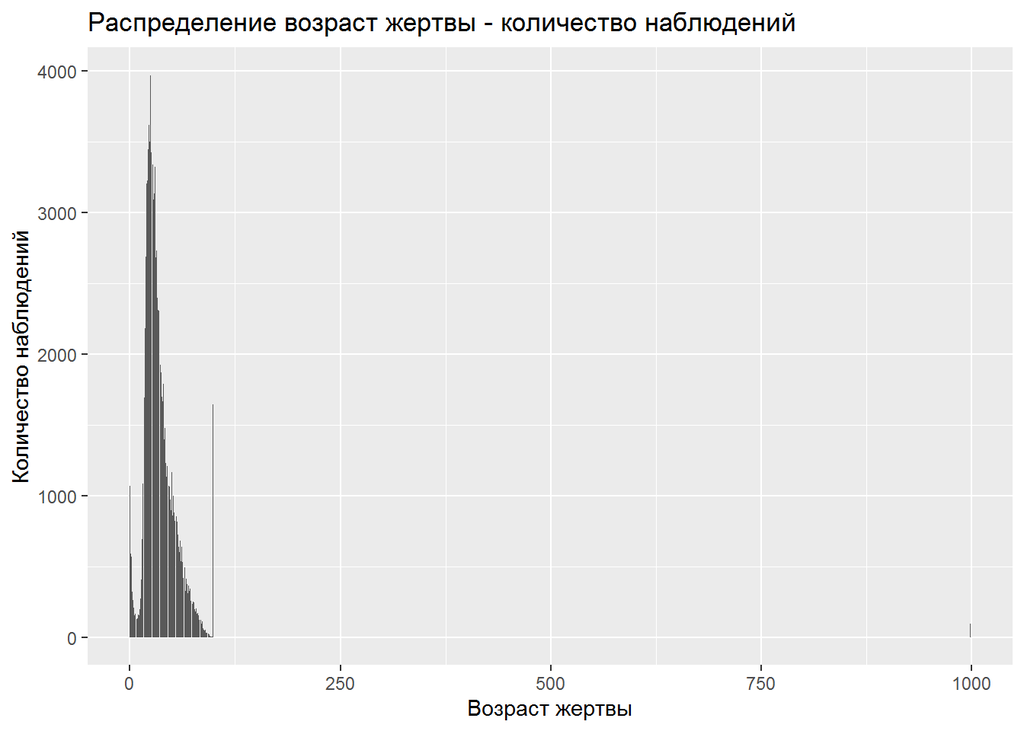

```r
ggplot(hc, aes(x = Victim_Age))+
  geom_bar()+
  labs(x = 'Возраст жертвы', y = 'Количество наблюдений',
       title = 'Распределение возраст жертвы - количество наблюдений')
```

В распределении возраста жертвы сразу заметны анамалии: люди с возрастом около 1000 лет и большое число людей в возрасте 99 лет.

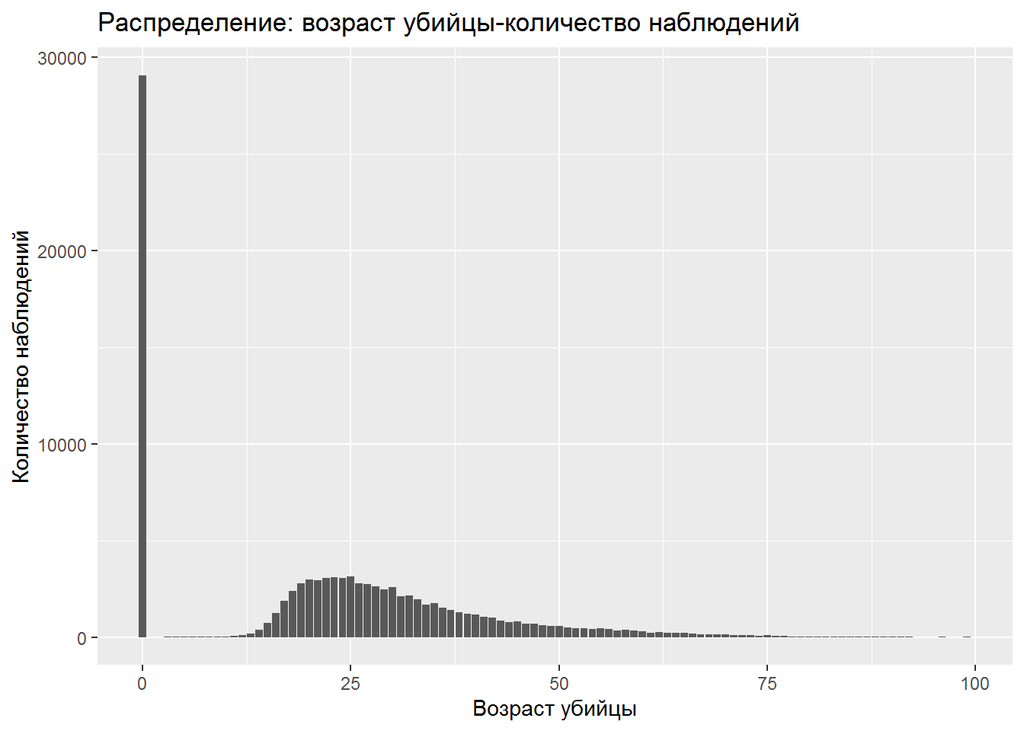

```r
ggplot(hc1, aes(x = Perpetrator_Age))+
  geom_bar()+
  labs(x = 'Возраст убийцы', y = 'Количество наблюдений',
       title = 'Распределение: возраст убийцы-количество наблюдений')
```

В распределении возраста преступников едниственная аномалия - 0 лет. Очевидно, что в таком возрасте человек физически не может быть преступником, скорее всего здесь 0 лет означает отсутсвие данных о возрасте преступника.

Исходя из того, что люди не живут 1000 лет, и что человек в 0 лет не может совершить преступление, изменяем набор данных для получения более адекватного распределения:

```r
hc4 <- hc1 %>%
   mutate(vage =
           ifelse(Victim_Age > 130, 100
                  , ifelse(Victim_Age == 0, "Unknown", Victim_Age))) %>%
  mutate(page =
           ifelse(Perpetrator_Age == 0, "Unknown", Perpetrator_Age))
```

Предполагая, что люди не живут более 130 лет, все люди старше 130 лет будут иметь возраст более реальный - 100 лет, преступники с возрастом 0 лет переведены в группу :возраст неизвестен “Unknown”.

Рассмторим получившееся распределение по возрасту жертв:

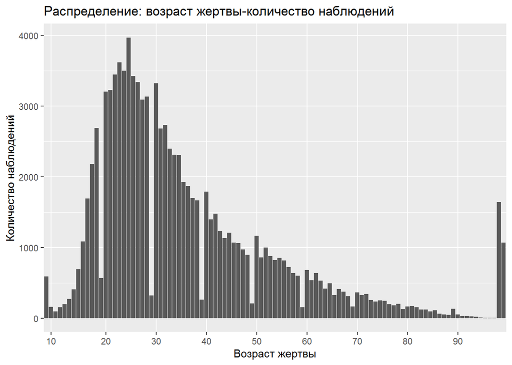

```r
ggplot(hc4, aes(x = vage))+
  geom_bar()+
   scale_x_discrete(breaks = c(0, 10, 20, 30, 40, 50, 60 ,70, 80, 90))+
  labs(x = 'Возраст жертвы', y = 'Количество наблюдений',
       title = 'Распределение: возраст жертвы-количество наблюдений')
```

Тем не менее, все равно наблюдаются выбросы 99 лет и 0 лет. Выброс на 0 лет выделяется на фоне других возрастных групп, однако данные в расмках этого распределения выглядят нормально, в отличии от 99 лет, которых чрезмерно много. Сложно сказать: насколько достоверны эти данные, но если опираться на то, что люди возрастои 90-98 лет являются жертами чрезмерно редко, то можно сделать вывод, что огромное наблюдение на 99 лет - это ошибка в данных. Поэтому, люди возрастом 99 лет и преступления, связанные с ними рассмотрены не будут для того, чтобы не искажать общую картину данных.

Уберем из распределения людей старше 98 лет.

```r
hc5 <-
  filter(hc4, !(vage > 98))
```

Теперь график распределения выглядит нормально, не имея серьезных выбросов и аномалий.

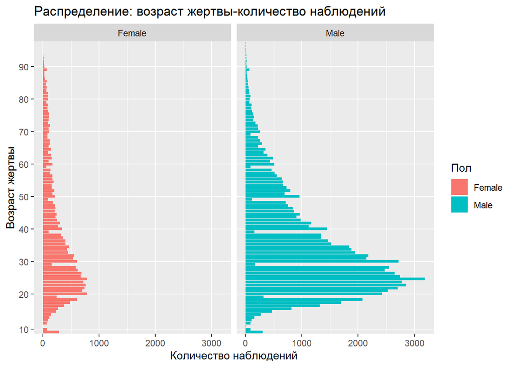

```r
hc5 %>%
  filter( !(Victim_Sex == "Unknown" )) %>%

ggplot(hc5, mapping = aes(x = vage))+
  geom_bar(aes(fill = Victim_Sex))+
  coord_flip()+
  facet_wrap(~Victim_Sex)+
  labs(x = 'Возраст жертвы', y = 'Количество наблюдений',
       title = 'Распределение: возраст жертвы-количество наблюдений', fill = 'Пол')+
     scale_x_discrete(breaks = c(0, 10, 20, 30, 40, 50, 60 ,70, 80, 90))
```

Также сразу разделим жертв по полам, чтобы в дальнейших исследованиях сразу сравнивать на этот факт. Сразу можно сделать вывод: женщин убивают гораздо реже, чем мужчин. Основной возраст жертвы: 20-35 лет обоих полов. Людей в США в таком возрасте - большинство, поэтому половозрастная диаграмма жертв выглядит вполне логично и достоверно.

Рапсределение по возрасту преступников также выглядит нормально.

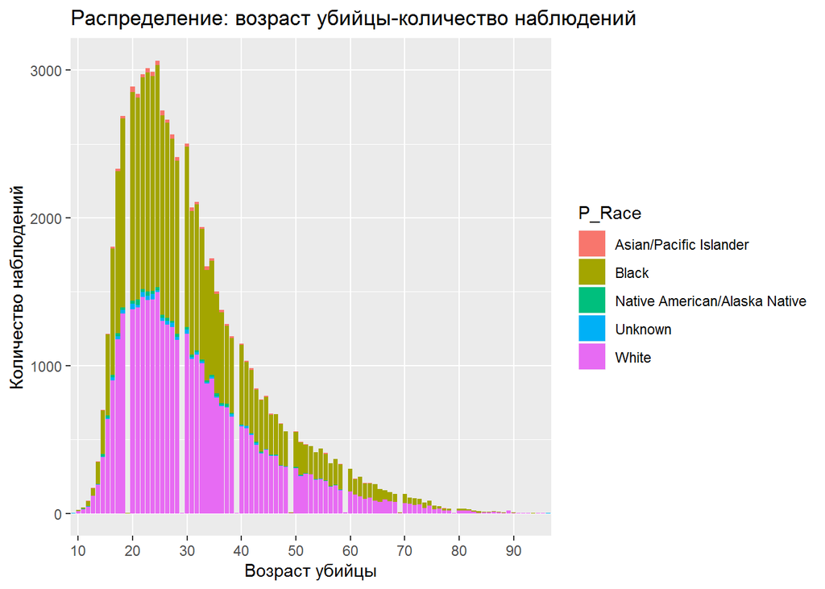

```r
hc5 %>%
  filter( !(page == "Unknown") ) %>%

ggplot(hc5, mapping = aes(x = page))+
  geom_bar(aes(fill = P_Race))+
  scale_x_discrete(breaks = c(0, 10, 20, 30, 40, 50, 60 ,70, 80, 90))+
  labs(x = 'Возраст убийцы', y = 'Количество наблюдений',
       title = 'Распределение: возраст убийцы-количество наблюдений')
```

Также, основное заключение: средний возраст убийцы: 18-35 лет.

То же распределение, но в “ящике с усами”:

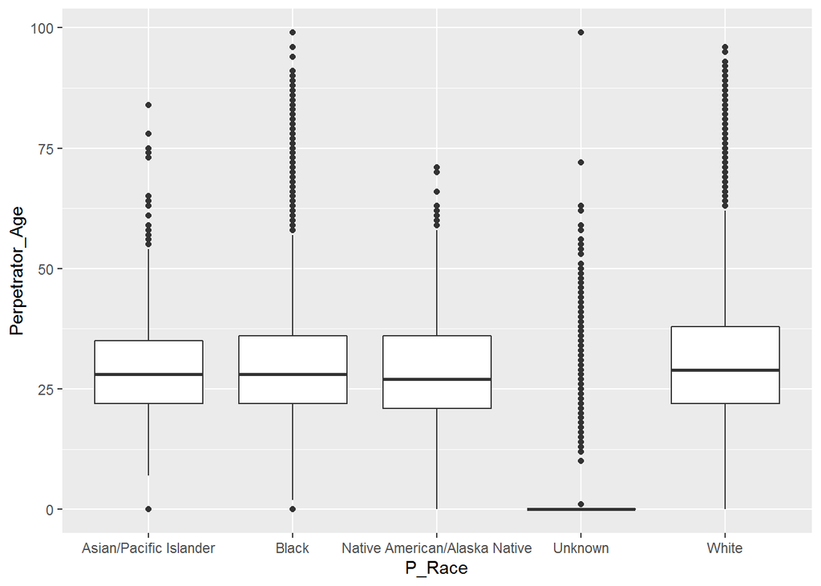

```r
ggplot(hc5, aes(x = P_Race, y = Perpetrator_Age))+
  geom_boxplot()
```

После сортировки данных можно преступать к их анализу.

###4) Разведочный анализ данных **1. Кто чаще убивает: женщины или мужчины?**

Чтобы определить: кто чаще убивает, построим распределение преступников по полу. Разделение преступников по полу.

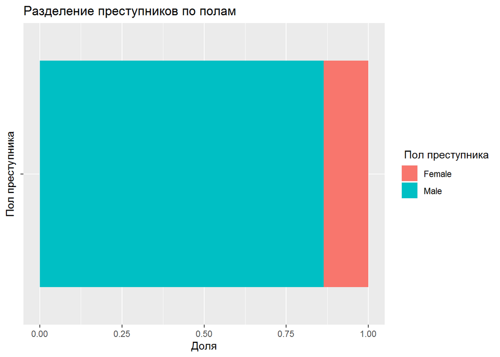

```r
hc5 %>% filter(Perpetrator_Sex=="Male" | Perpetrator_Sex=="Female") %>%

ggplot(hc5, mapping = aes(x = ""))+
 geom_bar(aes(fill  = Perpetrator_Sex), position = 'fill') +
 coord_flip()+
  labs(x = 'Пол преступника', y = 'Доля',
       title = 'Разделение преступников по полам') +
  labs(fill = ' Пол преступника')
```

Распределение показывает, что преимущественно преступниками являются мужчины (около 90%), женщин-убийц немногим более 10%. В распределении была убрана графа “Unknown”, чтобы анализировать только проверенные данные (очевидно, что преступники под “Unknown” пойманы не были).

Созданим распределение по возрастам и полам убийцы, чтобы выяснить: кто обычно является преступником, в зависимости от возрастной группы (молодой возраст - менее 20 лет, средний - 20-50 лет, и возраст выше среднего - более 50 лет).

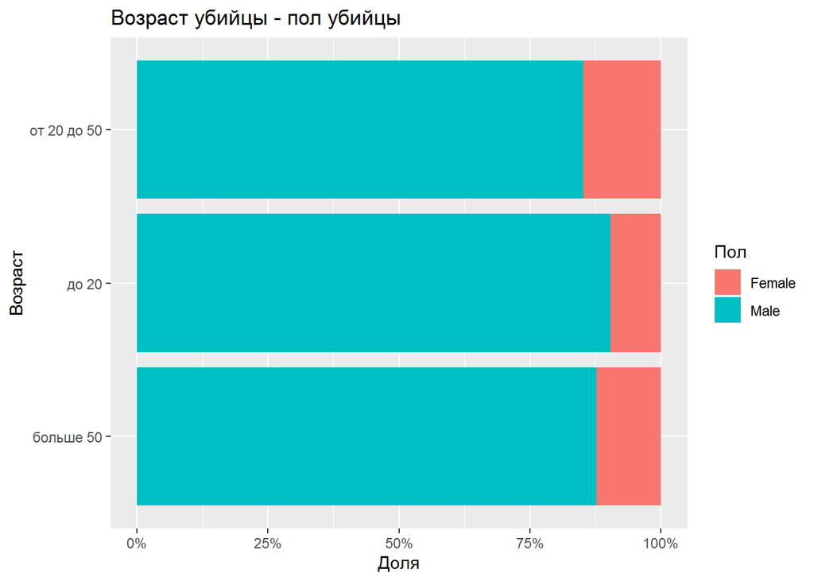

```r
hc6 <- hc5 %>%
  mutate(Page1 =
           ifelse(page < 21, "до 20", ifelse(page > 50, "больше 50", ifelse(page >= 21 & page <= 50, "от 20 до 50", "Unknown")))) %>%
  filter(!(Perpetrator_Sex == "Unknown"))



ggplot(hc6, aes(x = Page1))+
 geom_bar(aes(fill =Perpetrator_Sex), position = 'fill') +
 coord_flip()+
  labs(x = 'Возраст', y = 'Доля',
       title = 'Возраст убийцы - пол убийцы') +
  labs(fill = 'Пол')+
   scale_y_continuous(labels = percent)
```

Разделение убийц по полам и возрасту не показала неожиданных результатов. Мужчины во всех возрастах убивают больше, чем женщины, без явных зависимостей.

Распределение популярности орудий убийства по расам претсупников:

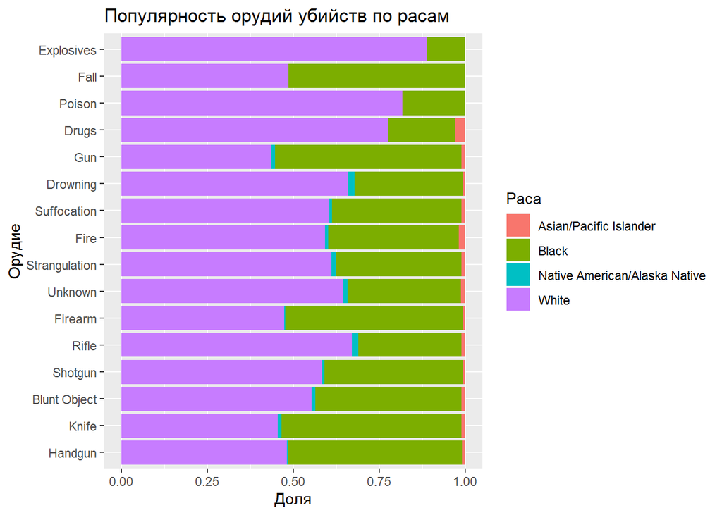

```r
hc5 %>% filter(Perpetrator_Sex=="Male" | Perpetrator_Sex=="Female") %>%
  filter(!(P_Race == "Unknown")) %>%


ggplot(hc5, mapping = aes(x = fct_infreq(Weapon), fill = P_Race))+
 geom_bar(aes(fill = P_Race), position = 'fill') +
 coord_flip()+

  labs(x = 'Орудие', y = 'Доля',
       title = 'Популярность орудий убийств по расам') +
  labs(fill = 'Раса')
```

Включая тот факт, что чернокожего населения в США - 13%, можно сделать вывод, что чернокожие преступники гораздо чаще используют огнестрельное оружие (handgun, gun, firearm) и ножи, чем белое население (которое состаляет 70% от общего населения). Таким образом, несмотря на то, что чернокожего населения в несколько раз ниже, чем белого, вероятность того, что преступником будет представитель чернокожего населения - около 50%.

**2. Какой самый популярный предмет для убийства среди женщин? А мужчин?**

Построим распределение по полам и орудиям убийств, которые используют преступники.

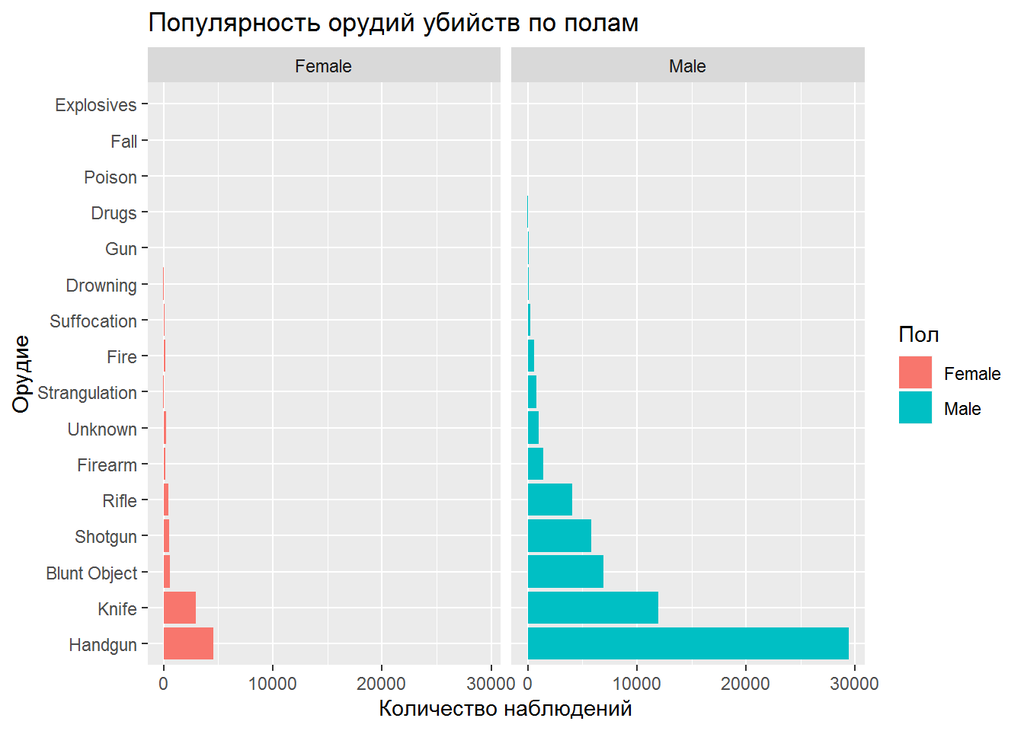

```r
hc5 %>% filter(Perpetrator_Sex=="Male" | Perpetrator_Sex=="Female") %>%


ggplot(hc5, mapping = aes(x = fct_infreq(Weapon)))+
 geom_bar(aes(fill = Perpetrator_Sex)) +
 coord_flip()+
    facet_grid(~Perpetrator_Sex)+
  labs(x = 'Орудие', y = 'Количество наблюдений',
       title = 'Популярность орудий убийств по полам') +
  labs(fill = 'Пол')
```

По распределению видно: самые популярные орудия убийства у женщин и мужчин одинаковы - это “handgun (пистолет)” и “нож”. Далее по популярности есть некоторые расхождения. У мужчин после ножа и пистолета идут (по порядку): “тупой предмет”,“дробовик”,“ружье”, “огнестрельное оружие”. Это перечисление орудий убийст у мужчин по популяронсти. У женщин, попмимо перечисленных орудий убиств, остальные орудия сильно не выделяются и используются попеременно с примерно одинаковой долей.

Распределение по типу убийства (халатность/намеренной убийство), и по типу орудий:

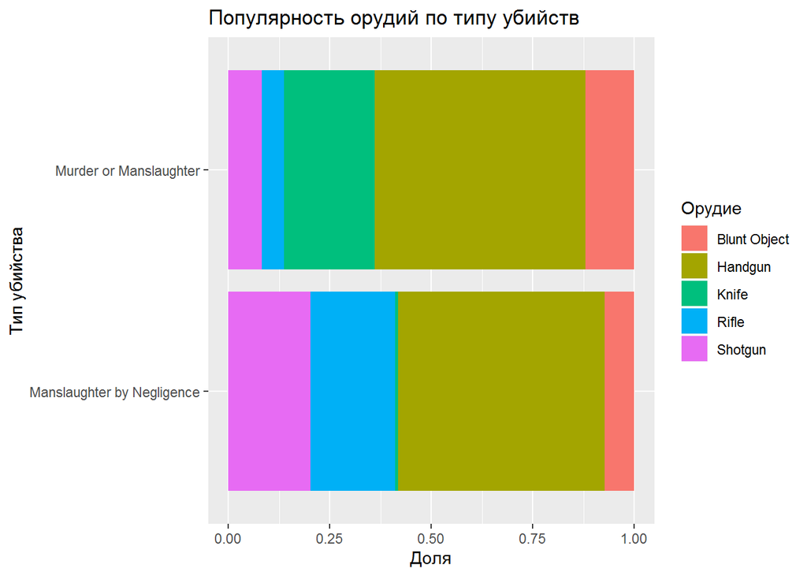

```r
hc5 %>%
  filter( Weapon == "Shotgun" |  Weapon == "Blunt Object" | Weapon == "Knife" |   Weapon == "Rifle" | Weapon == "Handgun"  ) %>%


ggplot(hc5, mapping = aes(x = Crime_Type, fill = Weapon))+
 geom_bar(aes(fill = Weapon), position = 'fill') +
 coord_flip()+

  labs(x = 'Тип убийства', y = 'Доля',
       title = 'Популярность орудий по типу убийств') +
  labs(fill = 'Орудие')
```

Рассмотрены 5 самых популярных орудий убийства по типу: преднамеренное - халатность. Как видно, чаще всего преднамеренной убийство (или по неосторожности) огнестрельным орудием ил ножом, в то время как по небрежности (халатности) - чаще всего это огнестрельное оружие. Распределение вполне логично: сложно предстваить, как человек по небрежности может убить ножом или тупым предметом. Таким образом, если у человека есть намерение совершить преступление, то скорее всего он будет использовать нож или огнестрельное орудие.

**3. В каком году было совершено больше всего преступлений? Какие могут быть причины?** Рапсределение убийств по годам 1980-1984.

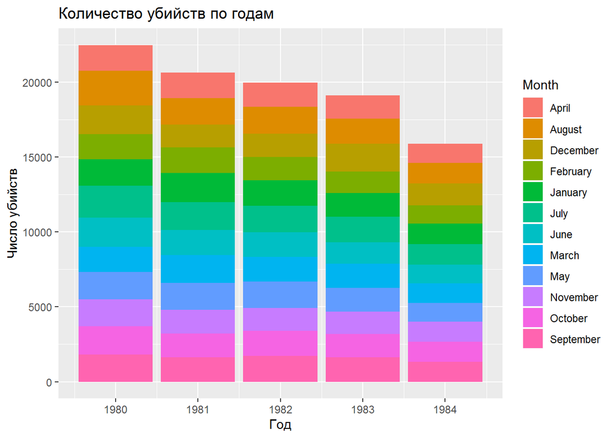

```r
ggplot(hc5, aes(x = Year), fill = Month)+
  geom_bar(aes(fill = Month))+
  labs(x = 'Год', y = 'Число убийств',
       title = 'Количество убийств по годам')
```

**4. В каких штатах преступления соершаются чаще, чем в остальных?** Распределение “количество убийств - штат”

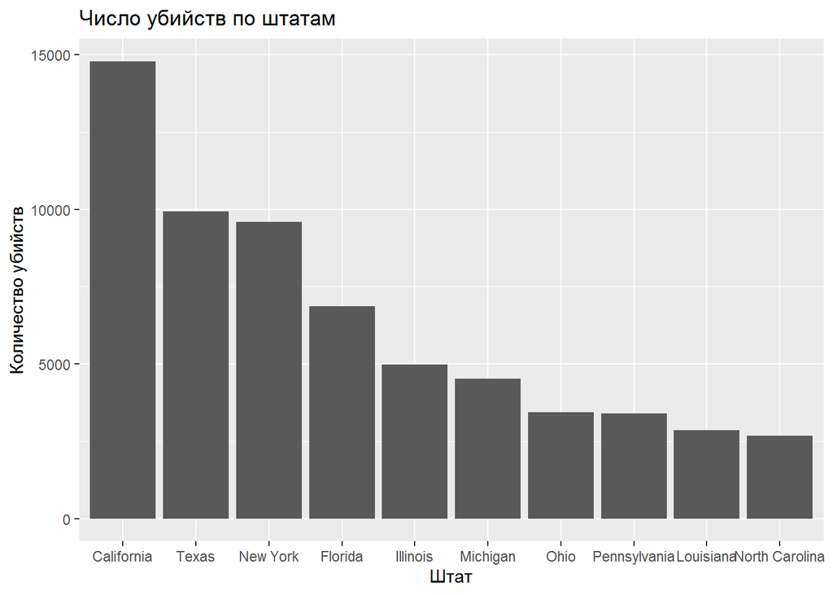

```r
hc5 %>%
  group_by(State) %>%
  tally() %>%
  top_n(10) %>%

ggplot(hc5, mapping = aes(x = reorder(State, -n), y=n) )+
  geom_bar( stat="identity")+
  labs(x = 'Штат', y = 'Количество убийств',
       title = 'Число убийств по штатам')
```

На распределении представлены топ-10 штатов по убийствам. Штаты с самыми частыми убийствами: Калифорния, Нью-Йорк, Техас. Распределение вполне логичное, так как в этих штатах живет наибольшее число людей, соотвественно и число преступлений больше.

**5. Сколько преступлений осталось не разрешенными? Есть ли по ним информация об убийце? Есть ли общие признаки по жертвам?**

Распределение: количество не/раскрытых преступлений.

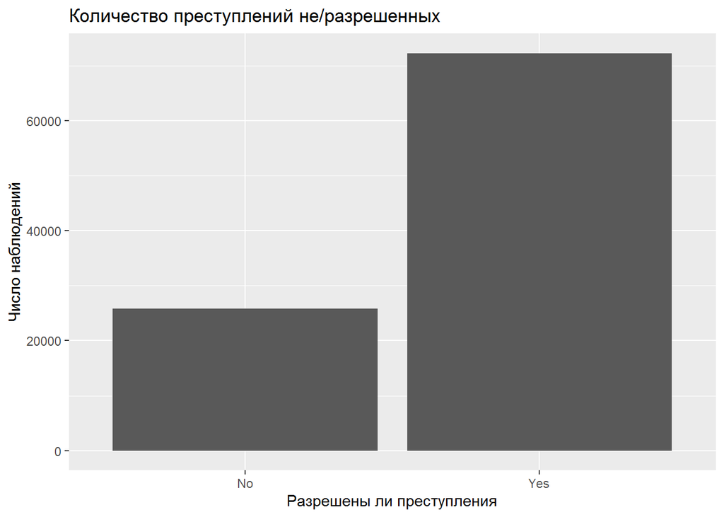

```r
ggplot(hc5, aes(x = Solved))+
  geom_bar()+
  labs(x = 'Разрешены ли преступления', y = 'Число наблюдений',
       title = 'Количество преступлений не/разрешенных')
```

Количество решенных преступлений - подавляющее большинство, однако количество неразрешенных состовляет треть от решенных, что является большой долей. В США достаточно большая доля нераскрытых преступлений.

Имеется ли какая-то информация о преступниках, чьи преступления не раскрыты:

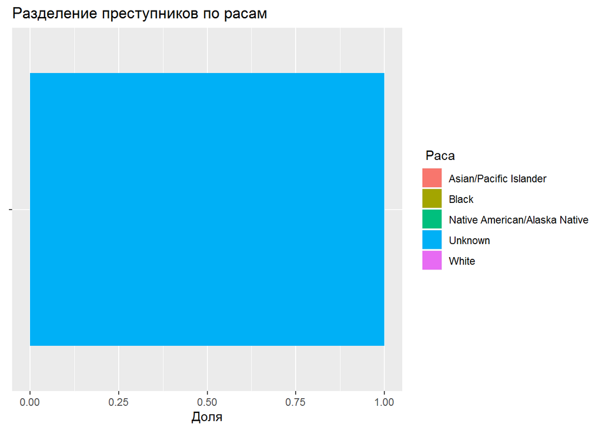

```r
hc5 %>% filter(Solved =="No") %>%

ggplot(hc5, mapping = aes(x = ""))+
 geom_bar(aes(fill  = P_Race), position = 'fill') +
 coord_flip()+
  labs(x = NULL, y = 'Доля',
       title = 'Разделение преступников по расам') +
  labs(fill = ' Раса')
```

Распределение показывает, что у преступников, которых не поймали, даже не установлена их раса (национальность). В таком случае, эти преступления никогда и не будут раскрыты.

Рапсределение по орудию убийства среди нераскрытых преступлений:

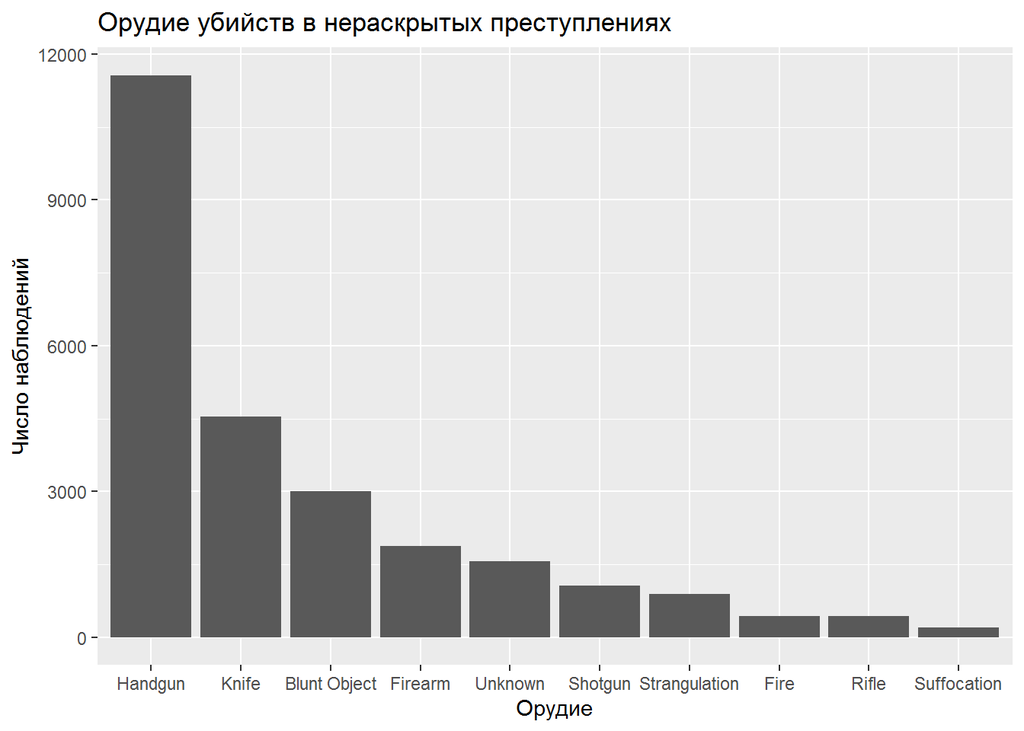

```r
hc5 %>%
  filter(Solved =="No") %>%
  group_by(Weapon) %>%
  tally() %>%
  top_n(10) %>%


ggplot(hc5, mapping = aes(x = reorder(Weapon, -n), y=n) )+
  geom_bar(  stat="identity")+
  labs(x = 'Орудие', y = 'Число наблюдений',
       title = 'Орудие убийств в нераскрытых преступлениях')
```

Данное распределение очень схоже с общим распределением по типу орудия убийства. То есть, власти в принципе не раскрывают преступления, и это не зависит от типа орудия. Однако, в большинстве случаев всегда убается установить орудие преступления, которое должно давать наводки на преступника.

Посмотрим: как распределены преступники по возрасту и по отношению к жертвам:

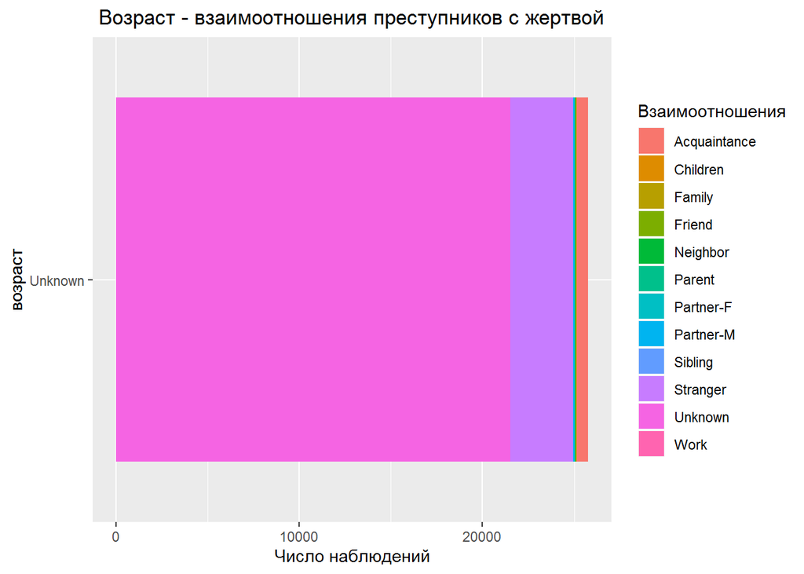

```r
hc5 %>%
  filter(Solved =="No") %>%
  filter(page =="Unknown") %>%


  ggplot(hc5, mapping = aes(x = page))+
  geom_bar(aes(fill = Rel_Category))+
  coord_flip()+
  labs(x = 'возраст', y = 'Число наблюдений',
       fill = 'Взаимоотношения', title = " Возраст - взаимоотношения преступников с жертвой")
```

Преступники, чьи дела нераскрыты не распределены по возрату, у полиции нет данных. По отношению к жертвам: в основном это “неизвестно”, “незнакомец” или “знакомый”. Сложно сделать какие-либо догадки насчет распределения, так как доля “неизвестно” занимает слишком большую часть для анализа.

Рапсределение жертв: половозрастная диаграмма с разделением на взаимоотношения с убийцей:

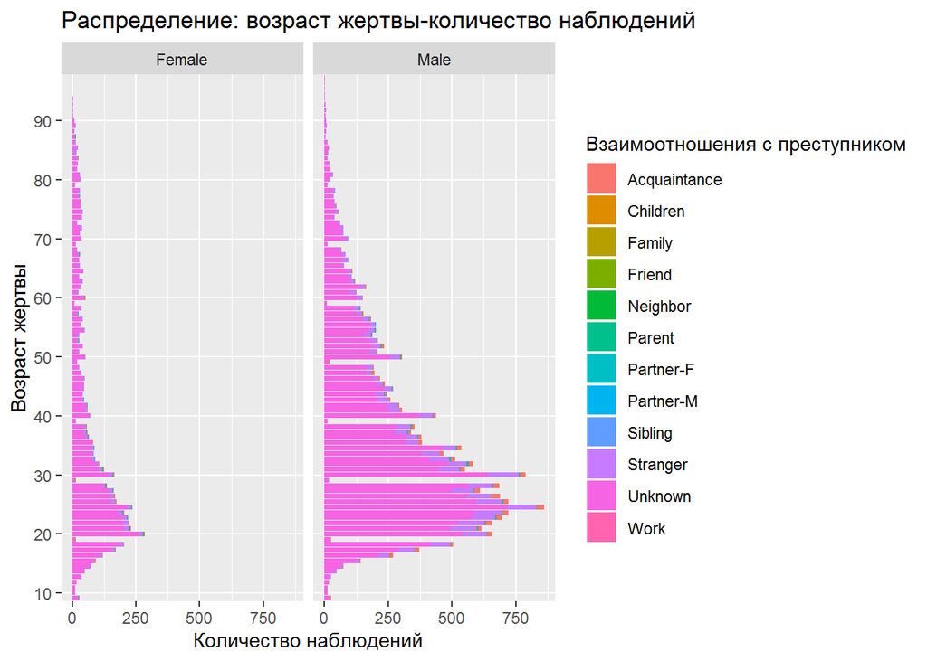

```r
hc5 %>%
  filter( !(Victim_Sex == "Unknown" )) %>%
  filter(Solved =="No") %>%

ggplot(hc5, mapping = aes(x = vage))+
  geom_bar(aes(fill = Rel_Category))+
  coord_flip()+
  facet_wrap(~Victim_Sex)+
  labs(x = 'Возраст жертвы', y = 'Количество наблюдений',
       title = 'Распределение: возраст жертвы-количество наблюдений', fill = 'Взаимоотношения с преступником')+
     scale_x_discrete(breaks = c(0, 10, 20, 30, 40, 50, 60 ,70, 80, 90))
```

Поповозрастная диаграмма жертв имеет схожее распределение с диаграммой по общим жертвам. Отсутсвие никаких типичных значений для нераскрытых убийств не выделяет эти преступления с основной массой, которые были раскрыты. Также как и там: основная масса жертв - 20-35 лет, в основном мужчины. Так как эти преступления не раскрыты, то не установлены и взаимоотношения с убийцей (чаще всего это неизвестно или незнакомец). Подавляющее большинство значений “неизвестно” не позволяет определить типичный портрет жертвы.

Распределение половозрастная диаграмма, разделенная дополнительно по расам жертв:

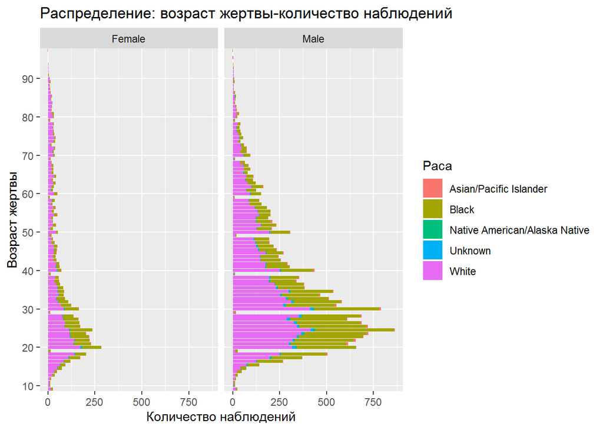

```r
hc5 %>%
  filter( !(Victim_Sex == "Unknown" )) %>%
  filter(Solved =="No") %>%

ggplot(hc5, mapping = aes(x = vage))+
  geom_bar(aes(fill = V_Race))+
  coord_flip()+
  facet_wrap(~Victim_Sex)+
  labs(x = 'Возраст жертвы', y = 'Количество наблюдений',
       title = 'Распределение: возраст жертвы-количество наблюдений', fill = 'Раса')+
     scale_x_discrete(breaks = c(0, 10, 20, 30, 40, 50, 60 ,70, 80, 90))
```

Как говорилось ранее, процент белого населения США - 70, на диаграмме видно, что в возрасте 20-40 лет доля чернокожего населения в качестве жертв достигает половины, несмотря на то, что численно их намного меньше. Возможно это связано с тем , что в США в 80-е годы разделение на национальности (расы) были более строгими, в основном чернокожее население представляло собой людей из гетто, с низкими доходами, следовательно среди них был повышен уровень преступности. Нередки бывали столкновения между различными группировками людей, представляющих чернокожее население. Этот соцтальный фактр объясняет большую долю жертв среди чернокожего населения, несмотря на то, что количественно их намного меньше белого.

Распределение: количество жертв убийцы - раскрытые преступления:

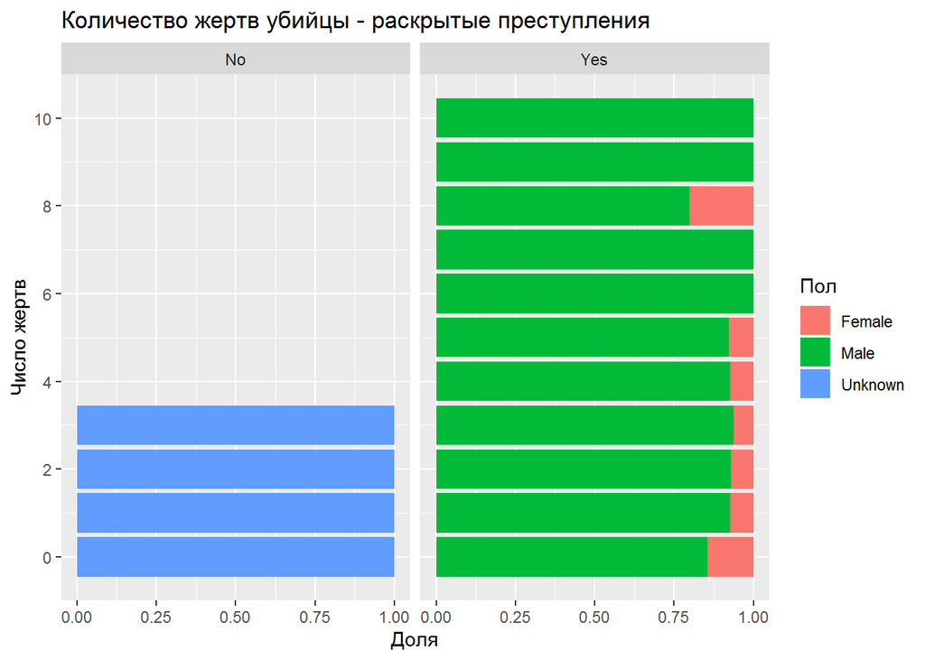

```r
ggplot(hc5, mapping = aes(x = P_Count))+
  geom_bar(aes(fill = Perpetrator_Sex), position = 'fill')+
  coord_flip()+
  facet_grid(~Solved)+
  scale_x_continuous(breaks = c(0, 2,  4,  6 , 8, 10))+
  labs(x = 'Число жертв', y = 'Доля',
       title = 'Количество жертв убийцы - раскрытые преступления', fill = 'Пол')
```

Так видно, что массовые убийства всегда раскрываются, в то время как убийства до 3 человек раскрываются не всегда. Скорее это связано с тем, что чем более убийств - тем больше улик, которые бы могли помочь раскрыть преступления.

**6. В каких штатах наибольший процент нерешенных преступлений? Кто чаще всего умирает в них? Какого возраста?**

Распределение: доля разрешенных преступлений по штатам:

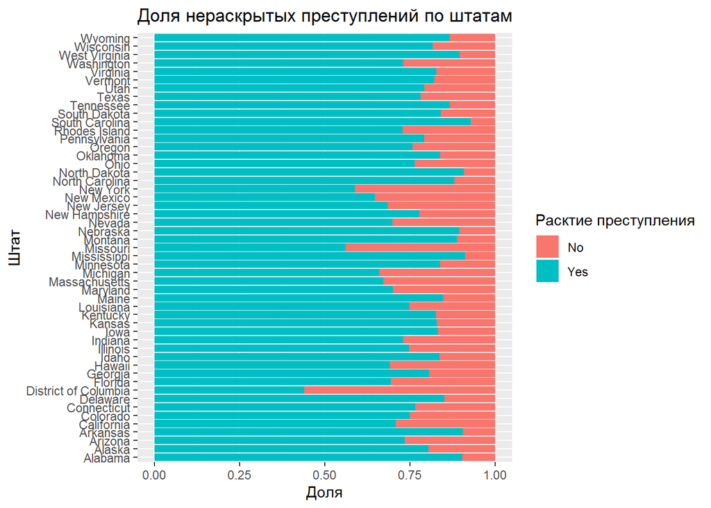

```r
 ggplot(hc5, mapping = aes(x = State, fill = Solved))+
  geom_bar(aes(fill = Solved), position = 'fill')+
  coord_flip()+
  labs(x = 'Штат', y = 'Доля',
       title = 'Доля нераскрытых преступлений по штатам', fill = 'Расктие преступления')
```

Для более детального анализа преступлений, отберем топ-5 штатов по неразрешенным преступлениям:

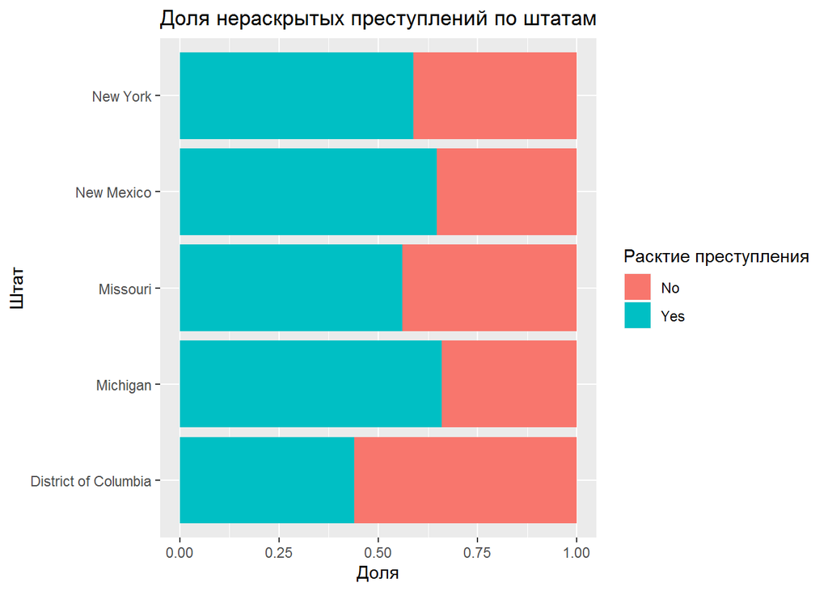

```r
hc5 %>%
  filter(State =="District of Columbia"| State == "Missouri"| State == "New York"| State =="New Mexico"| State == "Michigan") %>%


 ggplot(hc5, mapping = aes(x = State, fill = Solved))+
  geom_bar(aes(fill = Solved), position = 'fill')+
  coord_flip()+
labs(x = 'Штат', y = 'Доля',
       title = 'Доля нераскрытых преступлений по штатам', fill = 'Расктие преступления')
```

Такими оказались: Округ Колумбимя, Миссури, Мичиган, Нью Мексико и Нью Йорк. Процент неразрешенных преступлений колеблется от 30 до 55%. Эти штаты достаточно многочисленны, что ведет к тому, чем больше людей, чем больше преступлений - тем больше доля нераскрытых преступлений (мотивы которых неясны, так как в крупных городах люди могут совершать преступления, имея или неимея конкретных целей).

Исследуем: какие люди в основном убиты в штатах с наибольшей долей нераскрытых убийств: Рассмотрим половозрастную диаграмму:

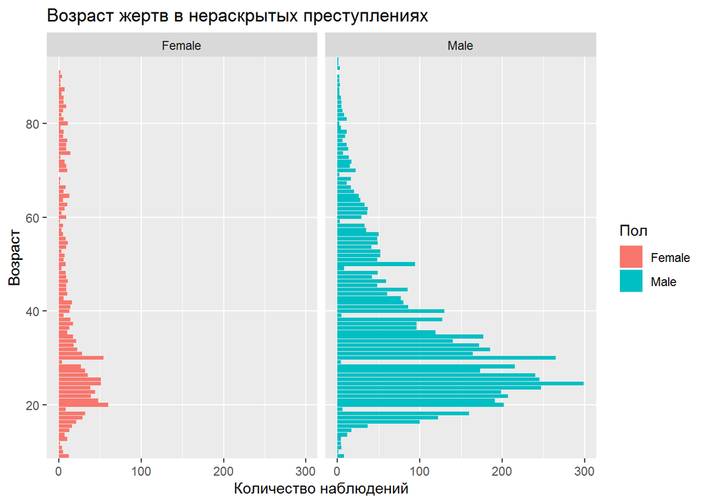

```r
hc5 %>%
  filter(State =="District of Columbia"| State == "Missouri"| State == "New York"| State =="New Mexico"| State == "Michigan", !(Victim_Sex == "Unknown" ), Solved =="No") %>%


  ggplot(hc5, mapping = aes(x = vage))+
  geom_bar(aes(fill = Victim_Sex))+
  coord_flip()+
  scale_x_discrete(breaks = c(0, 20,  40,  60 , 80))+
  facet_wrap(~Victim_Sex)+
  labs(x = 'Возраст', y = 'Количество наблюдений',
       title = 'Возраст жертв в нераскрытых преступлениях', fill = 'Пол')
```

Распределение ничем не выделяется, повторяет половозрастную диаграмму из пункта 1. Чаще всего - жертвы 20-40 лет, в основном мужчины, как и в общей половозрастной диаграмме жертв.

По отношению, в которых сотсояли жертва и преступник, строим распределение:

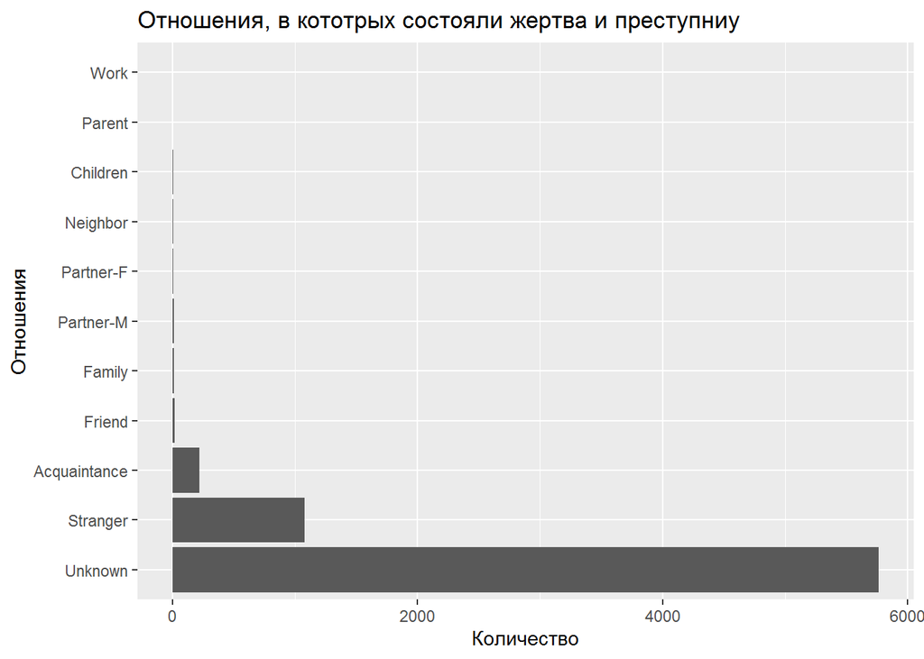

```r
hc5 %>%
  filter(State =="District of Columbia"| State == "Missouri"| State == "New York"| State =="New Mexico"| State == "Michigan", Solved == "No") %>%

  ggplot(hc5, mapping = aes(x = fct_infreq(Rel_Category)))+
  geom_bar()+
  coord_flip()+
  labs(x = 'Отношения', y = 'Количество',
       title = 'Отношения, в кототрых состояли жертва и преступниу')
```

Значение “неизвестно” занимает лидирующую строчку, что не удивительно, так как преступления были не раскрыты, а значит личность преступника и его взаимоотношений с жертвой не установлены. Далее идут отношения: “незнакомец” и “знакомый”. То есть, подалвющее большинтсво убийств были совершены людьми, которые с жертвой не сотсояли в близких или родственных отношениях. Можно предположить, что не раскрываются те преступления, в котрых нет явного мотива (так как жервта и убица либо не знакомы совсем, либо плохо знакомы).

Рапсределение по орудиям убийства:

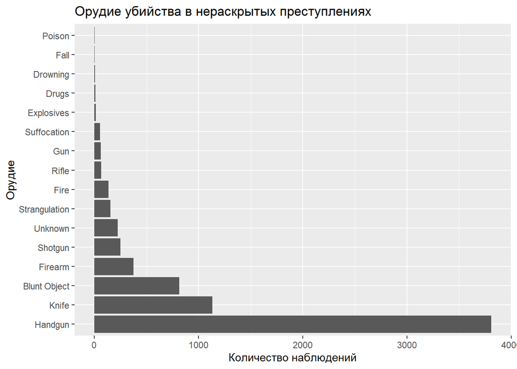

```r
hc5 %>%
 filter(State =="District of Columbia"| State == "Missouri"| State == "New York"| State =="New Mexico"| State == "Michigan", Solved == "No") %>%

  ggplot(hc5, mapping = aes(x = fct_infreq(Weapon)))+
  geom_bar()+
  coord_flip()+
  labs(x = 'Орудие', y = 'Количество наблюдений',
       title = 'Орудие убийства в нераскрытых преступлениях')
```

Частота убист орудиями очень схожа с распределениям по всем убийствам. Несмотря на нераскрытость преступления и отсутствие убийцы, тип орудия практически всегда устанавливают (с помощью свидетелей и изучения ран жертвы).

Рассмотрим, какой тип агенства расследовал преступление:

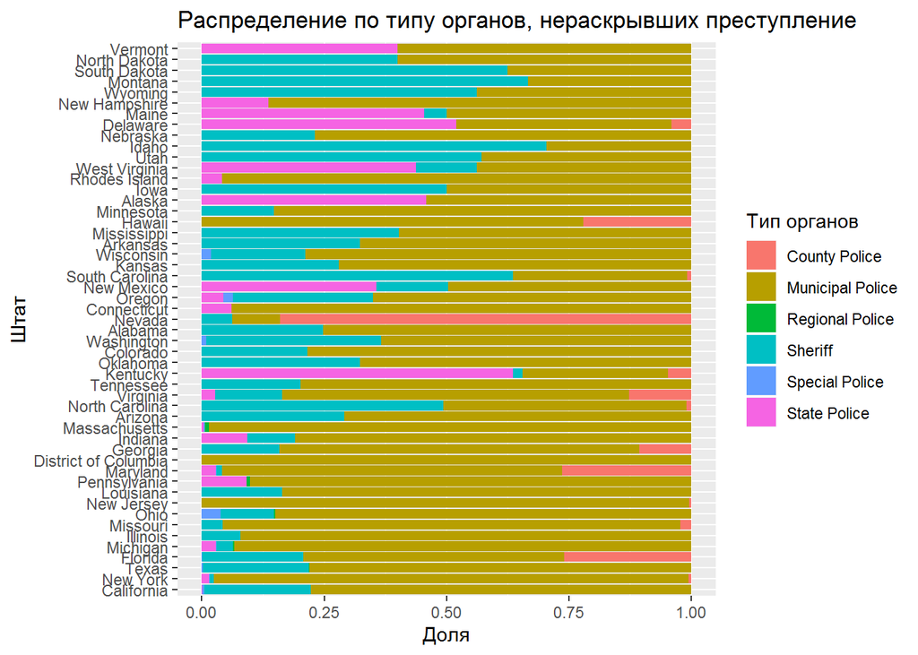

```r
hc5 %>%
  filter(Solved =="No") %>%


  ggplot(hc5, mapping = aes(x = fct_infreq(State)))+
  geom_bar(aes(fill = Agency_Type), position = 'fill')+
  coord_flip()+
  labs(x = 'Штат', y = 'Доля',
       title = 'Распределение по типу органов, нераскрывших преступление', fill = 'Тип органов')
```

###5) Итоговые результаты и выводы

**Наиболее наглядные и содержащие в себе полезную информацию визуализации:**

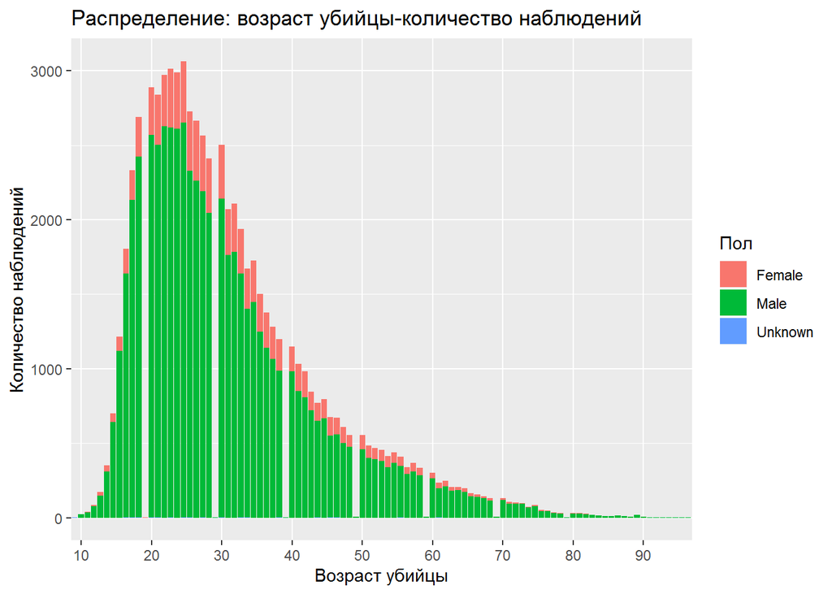

```r
hc5 %>%
  filter( !(page == "Unknown") ) %>%


ggplot(hc5, mapping = aes(x = page))+
  geom_bar(aes(fill = Perpetrator_Sex))+
  scale_x_discrete(breaks = c(0, 10, 20, 30, 40, 50, 60 ,70, 80, 90))+
  labs(x = 'Возраст убийцы', y = 'Количество наблюдений',
       title = 'Распределение: возраст убийцы-количество наблюдений', fill = 'Пол'
       )
```

1) Мужчины гораздо чаще являются преступниками 2) Средний возраст преступника 18-35 лет (то есть люди, еще не до конца утвердившиеся в жизни), с взрослением рост числа преступлений сильно падает.

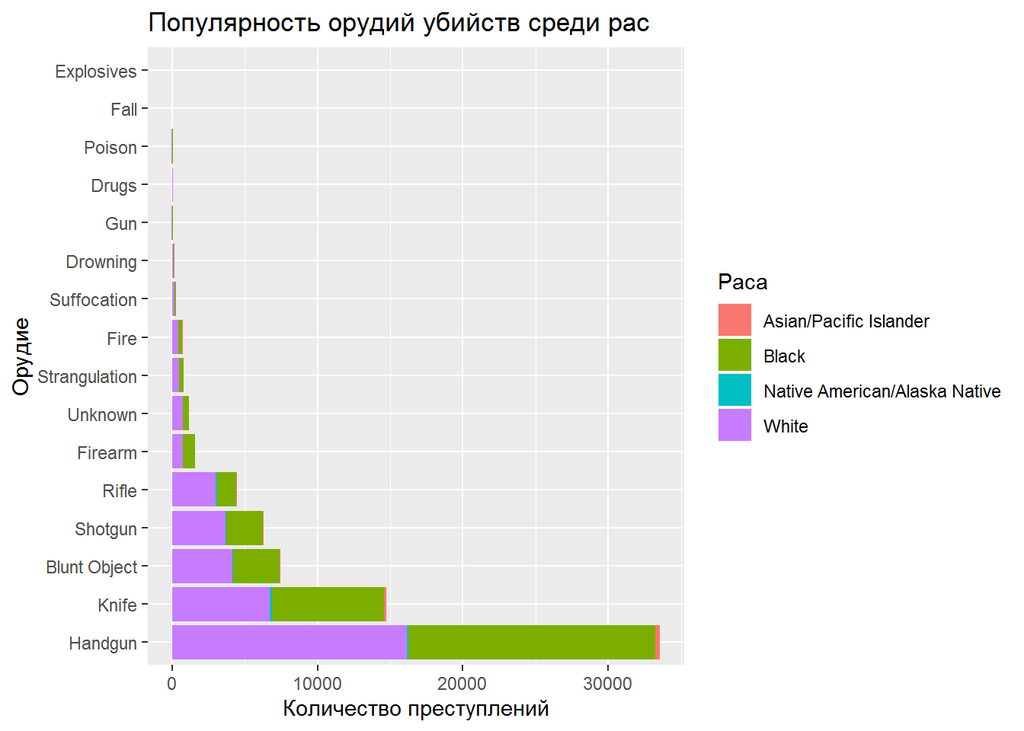

```r
hc5 %>%
  filter(!(P_Race == "Unknown")) %>%


ggplot(hc5, mapping = aes(x = fct_infreq(Weapon), fill = P_Race))+
 geom_bar(aes(fill = P_Race)) +
 coord_flip()+

  labs(x = 'Орудие', y = 'Количество преступлений',
       title = 'Популярность орудий убийств среди рас') +
  labs(fill = 'Раса')
```

1) Самые популярные орудия убийств: огнестрельное оружие (в первую очередь пистолет), нож и тупой предмет. 2) Высокая доля чернокожих преступников (до 50%), несмотря на то, что количественно их в разы меньше, чем белокожего населения

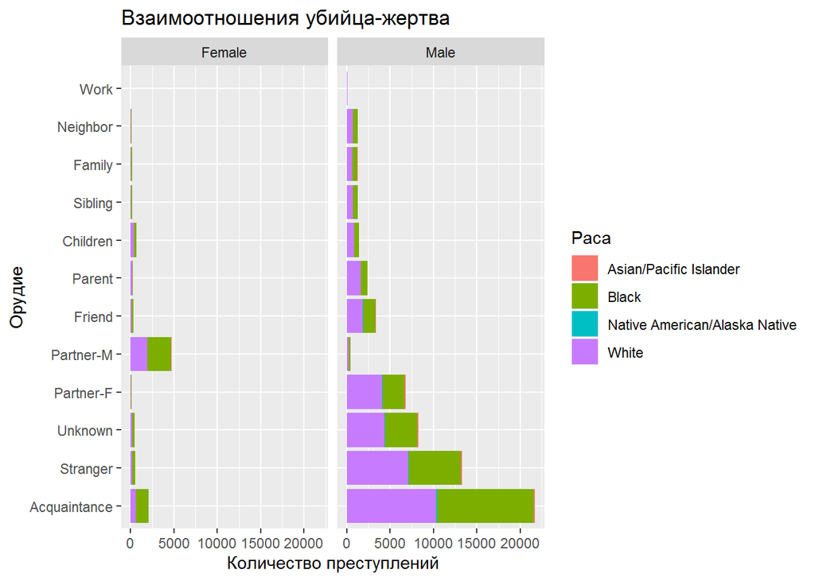

```r
hc5 %>% filter(Perpetrator_Sex=="Male" | Perpetrator_Sex=="Female") %>%
  filter(!(P_Race == "Unknown")) %>%


ggplot(hc5, mapping = aes(x = fct_infreq(Rel_Category), fill = P_Race))+
 geom_bar(aes(fill = P_Race)) +
 coord_flip()+

  labs(x = 'Орудие', y = 'Количество преступлений',
       title = 'Взаимоотношения убийца-жертва') +
  labs(fill = 'Раса')+
  facet_grid(~Perpetrator_Sex)
```

1) Большинство преступников находятся с жертвой не в близких отношениях (знакомый, незнакомец, “неизвестно”) 2) Причем женщины чаще всего убивают знакомых (в частности партнеров)

**Вывод: примерный портрет преступника-убийцы в США в 1980-е годы можно охарактеризовать так: мужчина, возрастом ниже средних лет (менее 45), жертву знает плохо либо совсем не знает, чаще всего совершает прествпление огнестрельным оружием либо пистолетом. Такое распределение по возрасту может значить, что человек еще не до конца утвердился в жизни, также есть тот факт, что молодые люди более склонны к переменам чем старые. Все это говорит о том, что молодое население более склонно к риску и к резким переменам, что может являться одним из факторов к совершению преступления. Это же подтвержает то, что с взрослением (до 20 лет) количество преступлений растет быстрее, чем оно убывает со старением (после 30 лет). Деление по расовому признаку не дает особой информации: практически поплам это либо представитель чернокожего, либо белокожего населения. Однако, процент белого населения США - 70, а чернокожего -13%, причем количество убийств делится между ними пополам. из чего делается вывод: что чернокожее население более склонно к преступлению, чем белое. Связано это в первую очередь с положением чернокожего населения в США, которые в те годы имели права в некоторых сферах ниже, чем у других слоев населения (не брали на определенную работу, не назначали на определенные должности), также большое количество чернокожего населения росло в гетто. В сосокупности эти факторы дали высокий рост преступности при небольшой численности. Распределение по взаимоотношениям между убийцей и жертвой показывает, что в основном люди убивают либо из-за личного конфликта (знакомые и партнеры), либо без личностного мотива (незнакомец - например, ограбление).**

**Примечание: представленные данные сильно ограничивают в разнообразии визуализации тем, что количественных столбцов всего несколько: возраст. количество убитых и года. Визуализация нескольких категоральных переменных в одном графике - весьма проблематично**